# Relatório Estatística Experimental

Guilherme Fernandes - 3398

Júlia Letícia - 3732

Victor Hugo - 3510

03/08/2022

# Introdução

Muito se discute sobre como a pandemia do COVID-19 afetou a maneira como o ser humano vivia. Trabalhadores, estudantes e crianças tiveram suas rotinas interrompidas e precisaram adaptar-se à situação. No caso dos estudantes e professores, houveram mudanças consideráveis no meio de ensino e consequentemente no método de ensino. De aulas presenciais e provas físicas no ensino presencial, os estudantes passaram a ter aulas gravadas ou síncronas e provas online no ensino remoto. Tais provas eram realizadas em plataformas digitais, bem como as plataformas oferecidas pela instituição de ensino, Google Forms, entre outras que surgiram durante a pandemia, que demandava um mínimo de conhecimento de uso da plataforma e uma conexão estável para realizar e enviar adequadamente a avaliação. À medida que a pandemia foi normalizando, a vida retomava ao normal e as instituições de ensino começaram, gradualmente, a retomar as atividades presenciais, principalmente as Universidades Federais em 2022. Porém 2 anos haviam passado e os estudantes e professores já estavam acostumados com a rotina toda sendo realizada dentro de casa e alguns alegavam que o ensino deveria continuar remoto. Afirmar qual dos métodos de ensino é melhor é uma tarefa árdua e devido a pandemia ainda não ter finalizado, de fato, em todo o mundo, fica difícil mensurar. Mas será que realmente há diferença de aprendizagem entre o presencial e o remoto? O objetivo deste relatório é apresentar o experimento elaborado e realizado, visando demonstrar se existe, de fato, alguma diferença entre ambos os métodos de ensino, avaliando o rendimento dos alunos por meio de avaliações das disciplinas iniciais dos cursos.

# Desenvolvimento

Para a realização do experimento 36 estudantes da Universidade Federal de Viçosa - campus Florestal se disponibilizaram a participar do mesmo de maneira voluntária, sendo 24 do curso Bacharelado em Ciência da Computação e 12 do curso Licenciatura em Matemática. Tais estudantes foram submetidos a uma prova de 20 questões referentes às matérias específicas do ciclo básico de ambas as graduações, sendo o ciclo básico considerado como as matérias do 1º e 2º período. Vale lembrar que dos 36 estudantes selecionados todos aprovaram nas matérias selecionadas e metade do grupo havia feito presencialmente, enquanto a outra metade realizou de forma remota.

# Materiais e Métodos

Os materiais e métodos utilizados foram:

- Google Forms: realização das provas;
- Laboratório de Informática da Matemática: local controlado para realização das provas;
- Excel: organização para a aplicação das provas para os estudantes e tratamento da base;
- R: ambiente de desenvolvimento utilizado para efetuar as análises, construção dos slides apresentados em aula no dia 04/08 e construção deste relatório;
- Github: ambiente para versionamento dos arquivos do R;
- ANOVA: método utilizado para analisar a base de dados obtida com a realização das provas.

# Provas

As provas realizadas foram o meio que os autores criaram para coletar determinadas características dos estudantes selecionados, além de avaliar o rendimento e efetuar as análises. Para a Ciência da Computação, as matérias selecionadas foram:

- Programação
- Matemática Discreta
- Introdução aos Sistemas Lógicos Digitais
- Algoritmos e Estruturas de Dados I.

Enquanto que para a Matemática, foram:

- Matemática Elementar
- Resolução de Problemas
- Introdução à Algebra
- Fundamentos de Geometria Plana e Desenho Geométrico

As características coletadas foram:

- Sexo
- Idade
- Curso
- Ano de ingresso na universidade
- Formato de conclusão das disciplinas: Presencial ou Remoto
- Tratamento: Com música ou Sem música. Será explicado em melhores detalhes na subseção 2.3
- Resposta das 20 questões
- Horário de início
- Horário de finalização

A coleta das características permitiu a construção de uma base de dados no software R, facilitando e possibilitando as análises. Além dessas características, a base de dados contém uma coluna para cada questão, indicando se o aluno acertou ou errou a questão correspondente. Além disso, foi necessário o controle da realização da prova, de modo a evitar colas ou a não realização do tratamento atribuído, e por esse motivo, as provas foram realizadas no Laboratório da Matemática, localizado na Universidade Federal de Viçosa - campus Florestal, com horário previamente marcado por meio da plataforma Doodle. Vale ressaltar que 5 alunos não puderam comparecer no laboratório nos horários em que algum dos autores estivesse lá presente e para contornar a situação, esses alunos fizeram suas provas na casa de 1 dos autores, com a mesma supervisão recebida no laboratório.

# Tratamentos

Para definir os tratamentos, o grupo decidiu atribuir um fator controlado aos estudantes que realizaram as provas:

- Efetuar a prova com música
- Efetuar a prova sem música

Dos 18 alunos que concluíram as matérias de forma presencial, 9 realizaram com música e o restante sem música. O mesmo foi atribuído aos alunos que concluíram as matérias de forma remota. Sendo assim, com o bloco Presencial e Remoto e os fatores controlados determinados, têm-se os seguintes tratamentos para o experimento em questão:

- Remoto, com música
- Remoto, sem música
- Presencial, com música
- Presencial, sem música

# Delineamento

De acordo com os tratamentos mencionados anteriormente, o grupo utilizou, então, um delineamento em blocos casualizados (DBC), obtendo os seguintes blocos:

# Análises

O objetivo de todas as análises a seguir é focado na variável numero_acertos que representa porcentagem de acertos nas avaliações.

# Análise Geral

## Por Formato de Ensino

| Variável | formato_ensino | Mediana | Média | Mínimo | Máximo | Desvio.Padrão | Variância | N |
| --- | --- | --- | --- | --- | --- | --- | --- | --- |
| numero_acertos | Presencial | 60.00 | 60.00 | 40.00 | 80.00 | 11.50 | 132.35 | 18 |
| numero_acertos | Remoto | 55.00 | 55.83 | 30.00 | 75.00 | 14.88 | 221.32 | 18 |
| idade | Presencial | 22.00 | 23.28 | 21.00 | 30.00 | 2.27 | 5.15 | 18 |
| idade | Remoto | 20.00 | 19.89 | 19.00 | 22.00 | 0.90 | 0.81 | 18 |
| duracao | Presencial | 19.35 | 28.73 | 11.47 | 73.17 | 19.54 | 381.69 | 18 |
| duracao | Remoto | 13.63 | 21.26 | 7.28 | 70.40 | 17.82 | 317.61 | 18 |

| Variável | Grupo | formato_ensino | N |
| --- | --- | --- | --- |
| sexo | Feminino | Presencial | 2 |
| sexo | Feminino | Remoto | 9 |
| sexo | Masculino | Presencial | 16 |
| sexo | Masculino | Remoto | 9 |
| ano_ingresso | 2016 | Presencial | 3 |
| ano_ingresso | 2017 | Presencial | 1 |
| ano_ingresso | 2018 | Presencial | 8 |
| ano_ingresso | 2019 | Presencial | 6 |
| ano_ingresso | 2020 | Remoto | 9 |
| ano_ingresso | 2021 | Remoto | 9 |
| tratamento | Com música | Presencial | 9 |
| tratamento | Com música | Remoto | 9 |
| tratamento | Sem música | Presencial | 9 |
| tratamento | Sem música | Remoto | 9 |
| curso | CDC | Presencial | 12 |
| curso | CDC | Remoto | 12 |
| curso | MAT | Presencial | 6 |
| curso | MAT | Remoto | 6 |

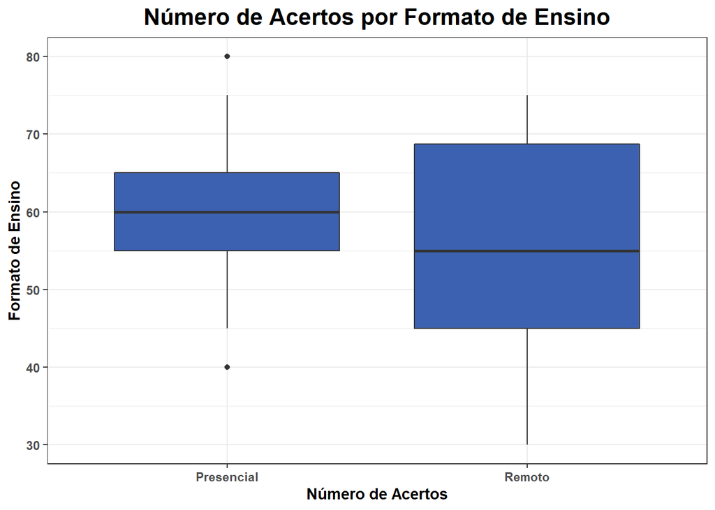

#### Hipótese

$$H_0: \mu_{\text{presencial}} =
\mu_{\text{remoto}}$$

Variável

Graus de Liberdade

Soma dos Quadrados

Média SQ

Valor F

P Valor

Formato do Ensino

1

156.25

156.250

0.884

0.354

Resíduos

34

6012.50

176.838

Como o P Valor é maior do que 0.05, não se rejeita $H_0$ a um nível de significância $\alpha$ de 5%.

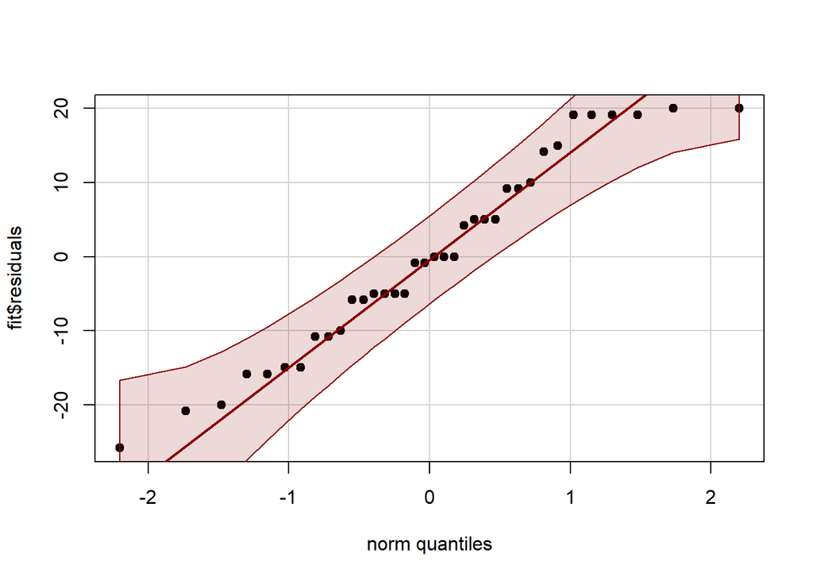

```
##
##  Shapiro-Wilk normality test
##
## data:  fit$residuals
## W = 0.95488, p-value = 0.1489
```

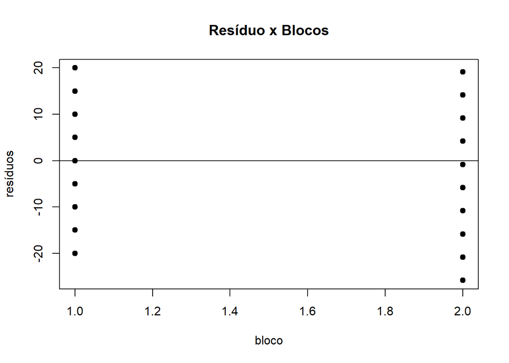

```
##
##  Bartlett test of homogeneity of variances
##
## data:  fit$residuals by df[, bloco]
## Bartlett's K-squared = 1.0796, df = 1, p-value = 0.2988
```

# Análise Geral

## Por Tratamento

| Variável | tratamento | Mediana | Média | Mínimo | Máximo | Desvio.Padrão | Variância | N |
| --- | --- | --- | --- | --- | --- | --- | --- | --- |
| numero_acertos | Com música | 65.00 | 62.50 | 35.00 | 80.00 | 13.09 | 171.32 | 18 |
| numero_acertos | Sem música | 55.00 | 53.33 | 30.00 | 75.00 | 12.13 | 147.06 | 18 |
| idade | Com música | 21.50 | 21.72 | 19.00 | 30.00 | 2.80 | 7.86 | 18 |
| idade | Sem música | 21.00 | 21.44 | 19.00 | 26.00 | 2.04 | 4.14 | 18 |
| duracao | Com música | 15.80 | 27.32 | 10.98 | 73.17 | 21.94 | 481.37 | 18 |
| duracao | Sem música | 18.42 | 22.67 | 7.28 | 70.40 | 15.36 | 236.04 | 18 |

| Variável | Grupo | tratamento | N |
| --- | --- | --- | --- |
| sexo | Feminino | Com música | 5 |
| sexo | Feminino | Sem música | 6 |
| sexo | Masculino | Com música | 13 |
| sexo | Masculino | Sem música | 12 |
| ano_ingresso | 2016 | Com música | 2 |
| ano_ingresso | 2016 | Sem música | 1 |
| ano_ingresso | 2017 | Com música | 1 |
| ano_ingresso | 2018 | Com música | 3 |
| ano_ingresso | 2018 | Sem música | 5 |
| ano_ingresso | 2019 | Com música | 3 |
| ano_ingresso | 2019 | Sem música | 3 |
| ano_ingresso | 2020 | Com música | 4 |
| ano_ingresso | 2020 | Sem música | 5 |
| ano_ingresso | 2021 | Com música | 5 |
| ano_ingresso | 2021 | Sem música | 4 |
| formato_ensino | Presencial | Com música | 9 |
| formato_ensino | Presencial | Sem música | 9 |
| formato_ensino | Remoto | Com música | 9 |
| formato_ensino | Remoto | Sem música | 9 |
| curso | CDC | Com música | 12 |
| curso | CDC | Sem música | 12 |
| curso | MAT | Com música | 6 |
| curso | MAT | Sem música | 6 |

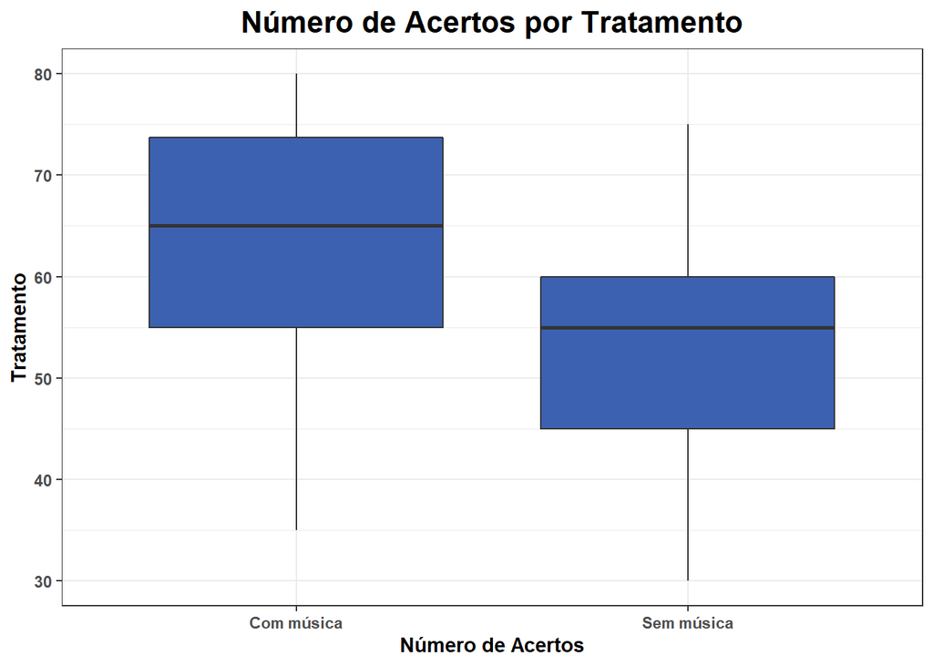

#### Hipótese

$$H_0: \mu_{\text{Com música}} =
\mu_{\text{Sem música}}$$

Variável

Graus de Liberdade

Soma dos Quadrados

Média SQ

Valor F

P Valor

Tratamento

1

756.25

756.250

4.751

0.036

Resíduos

34

5412.50

159.191

Como o P Valor é menor do que 0.05, se rejeita $H_0$ a um nível de significância $\alpha$ de 5%. Ou seja, a média da porcentagem de acertos de alunos que fizeram a prova com música é diferente da média da porcentagem de acertos de alunos que fizeram a prova sem música. Pela descritiva é possível ver que os alunos que fizeram a prova com música tiveram uma maior média de acertos.

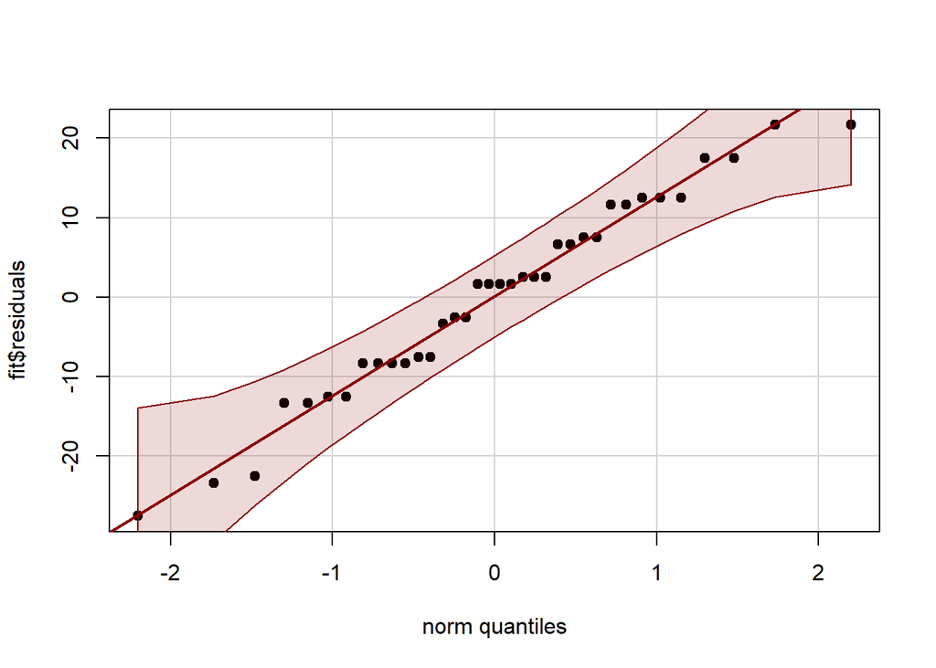

```
##
##  Shapiro-Wilk normality test
##
## data:  fit$residuals
## W = 0.97355, p-value = 0.53
```

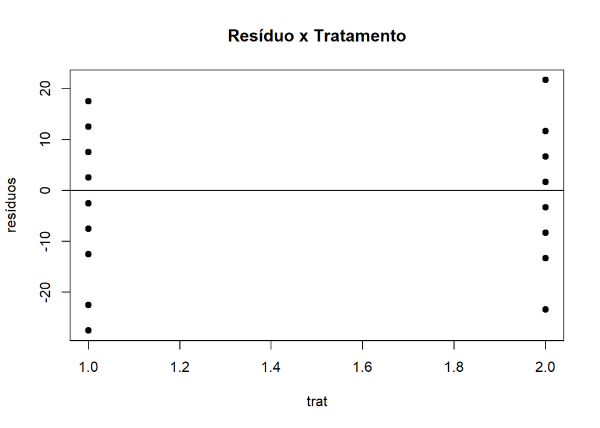

```
##
##  Bartlett test of homogeneity of variances
##
## data:  fit$residuals by df[, trat]
## Bartlett's K-squared = 0.0962, df = 1, p-value = 0.7564
```

## Por Formato de Ensino e Tratamento

| Variável | formato_ensino | tratamento | Mediana | Máximo | Desvio.Padrão | Variância | N |
| --- | --- | --- | --- | --- | --- | --- | --- |
| numero_acertos | Presencial | Com música | 65.00 | 80.00 | 10.31 | 106.25 | 9 |
| numero_acertos | Presencial | Sem música | 55.00 | 75.00 | 10.90 | 118.75 | 9 |
| numero_acertos | Remoto | Com música | 65.00 | 75.00 | 15.61 | 243.75 | 9 |
| numero_acertos | Remoto | Sem música | 50.00 | 75.00 | 13.69 | 187.50 | 9 |
| idade | Presencial | Com música | 22.00 | 30.00 | 2.83 | 8.03 | 9 |
| idade | Presencial | Sem música | 22.00 | 26.00 | 1.66 | 2.75 | 9 |
| idade | Remoto | Com música | 20.00 | 22.00 | 1.05 | 1.11 | 9 |
| idade | Remoto | Sem música | 20.00 | 21.00 | 0.78 | 0.61 | 9 |
| duracao | Presencial | Com música | 16.13 | 73.17 | 26.09 | 680.91 | 9 |
| duracao | Presencial | Sem música | 23.82 | 45.12 | 10.25 | 105.04 | 9 |
| duracao | Remoto | Com música | 15.38 | 56.32 | 17.06 | 291.18 | 9 |
| duracao | Remoto | Sem música | 13.58 | 70.40 | 19.49 | 379.86 | 9 |

| Variável | Grupo | formato_ensino | tratamento | N |
| --- | --- | --- | --- | --- |
| sexo | Feminino | Presencial | Com música | 1 |
| sexo | Feminino | Presencial | Sem música | 1 |
| sexo | Feminino | Remoto | Com música | 4 |
| sexo | Feminino | Remoto | Sem música | 5 |
| sexo | Masculino | Presencial | Com música | 8 |
| sexo | Masculino | Presencial | Sem música | 8 |
| sexo | Masculino | Remoto | Com música | 5 |
| sexo | Masculino | Remoto | Sem música | 4 |
| ano_ingresso | 2016 | Presencial | Com música | 2 |
| ano_ingresso | 2016 | Presencial | Sem música | 1 |
| ano_ingresso | 2017 | Presencial | Com música | 1 |
| ano_ingresso | 2018 | Presencial | Com música | 3 |
| ano_ingresso | 2018 | Presencial | Sem música | 5 |
| ano_ingresso | 2019 | Presencial | Com música | 3 |
| ano_ingresso | 2019 | Presencial | Sem música | 3 |
| ano_ingresso | 2020 | Remoto | Com música | 4 |
| ano_ingresso | 2020 | Remoto | Sem música | 5 |
| ano_ingresso | 2021 | Remoto | Com música | 5 |
| ano_ingresso | 2021 | Remoto | Sem música | 4 |
| curso | CDC | Presencial | Com música | 6 |
| curso | CDC | Presencial | Sem música | 6 |
| curso | CDC | Remoto | Com música | 6 |
| curso | CDC | Remoto | Sem música | 6 |
| curso | MAT | Presencial | Com música | 3 |
| curso | MAT | Presencial | Sem música | 3 |
| curso | MAT | Remoto | Com música | 3 |
| curso | MAT | Remoto | Sem música | 3 |

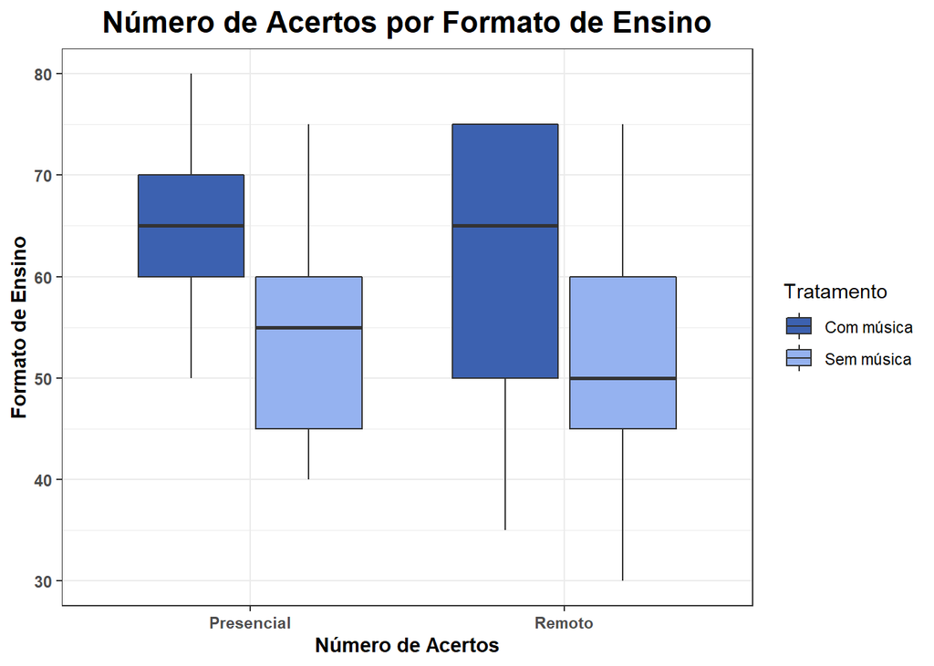

#### Hipótese

$$H_0: \mu_{\text{Com música:Presencial}}
= \mu_{\text{Com música:Remoto}} = \\ \mu_{\text{Sem música:Presencial}}
= \mu_{\text{Sem música:Remoto}}$$

Variável

Graus de Liberdade

Soma dos Quadrados

Média SQ

Valor F

P Valor

Formato do Ensino

1

156.25

156.250

0.952

0.336

Tratamento

1

756.25

756.250

4.61

0.039

Formato do Ensino : Tratamento

1

6.25

6.250

0.038

0.846

Resíduos

32

5250.00

164.062

Como o P Valor é maior do que 0.05, não se rejeita $H_0$ a um nível de significância $\alpha$ de 5%. Lembrando que a hipótese é referente a Variável Formato do Ensino : Tratamento.

Mas olhando para a variável Tratamento, o P Valor foi menor do que 0.05, ou seja, a uma diferença entre os tratamentos quando separamos por formato do ensino como pode ser observado no Boxplot anterior.

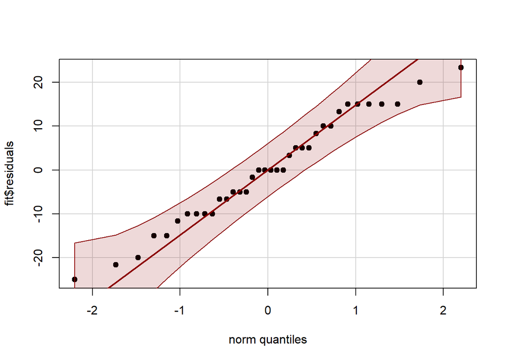

```
##
##  Shapiro-Wilk normality test
##
## data:  fit$residuals
## W = 0.97602, p-value = 0.6103
```

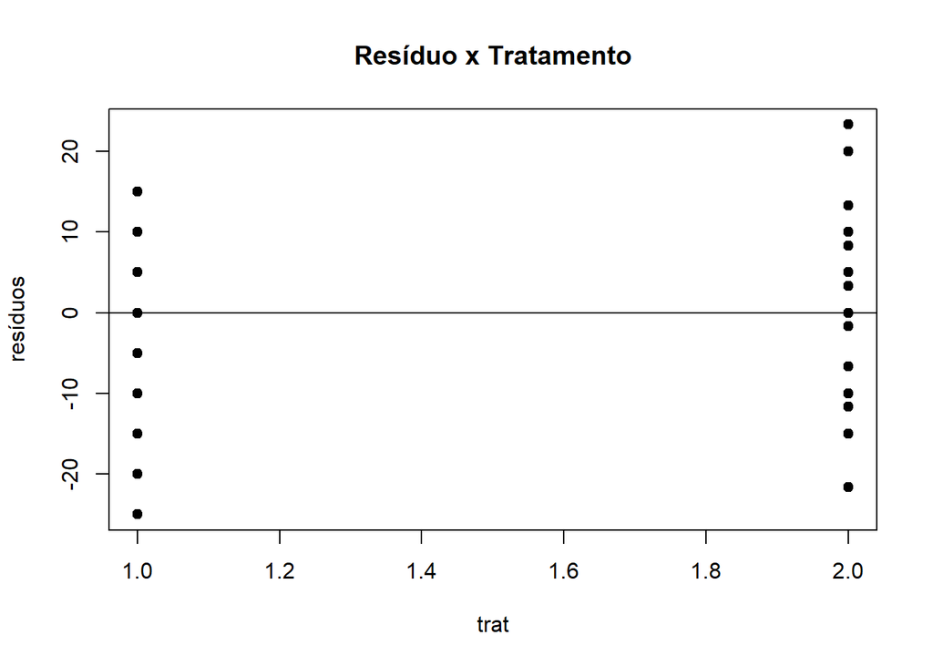

```
##
##  Bartlett test of homogeneity of variances
##
## data:  fit$residuals by df[, trat]
## Bartlett's K-squared = 0.07356, df = 1, p-value = 0.7862
```

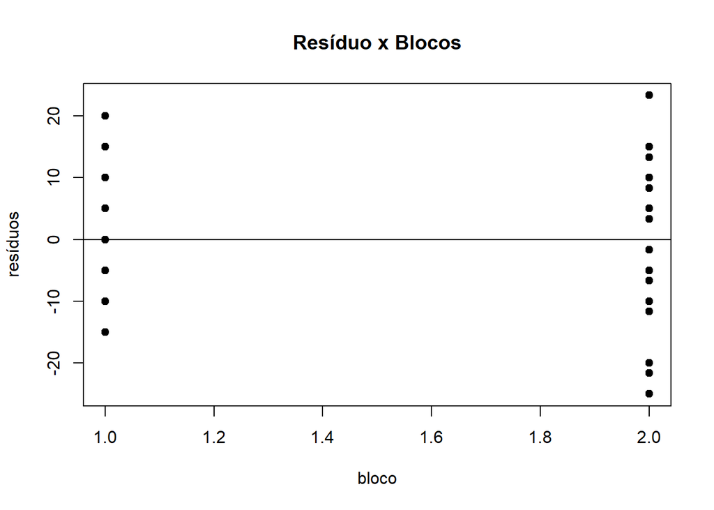

```
##
##  Bartlett test of homogeneity of variances
##
## data:  fit$residuals by df[, bloco]
## Bartlett's K-squared = 1.7175, df = 1, p-value = 0.19
```

# Análise Ciência da Computação

## Por Formato de Ensino

| Variável | formato_ensino | Mediana | Média | Mínimo | Máximo | Desvio.Padrão | Variância | N |
| --- | --- | --- | --- | --- | --- | --- | --- | --- |
| numero_acertos | Presencial | 60.00 | 60.42 | 45.00 | 75.00 | 8.11 | 65.72 | 12 |
| numero_acertos | Remoto | 55.00 | 55.42 | 30.00 | 75.00 | 14.53 | 211.17 | 12 |
| idade | Presencial | 23.50 | 24.08 | 22.00 | 30.00 | 2.39 | 5.72 | 12 |
| idade | Remoto | 20.00 | 20.08 | 19.00 | 21.00 | 0.67 | 0.45 | 12 |
| duracao | Presencial | 16.23 | 17.63 | 11.47 | 27.07 | 4.60 | 21.14 | 12 |
| duracao | Remoto | 12.83 | 12.81 | 7.28 | 17.58 | 2.70 | 7.31 | 12 |

| Variável | Grupo | formato_ensino | N |
| --- | --- | --- | --- |
| sexo | Feminino | Remoto | 5 |
| sexo | Masculino | Presencial | 12 |
| sexo | Masculino | Remoto | 7 |
| ano_ingresso | 2016 | Presencial | 3 |
| ano_ingresso | 2017 | Presencial | 1 |
| ano_ingresso | 2018 | Presencial | 7 |
| ano_ingresso | 2019 | Presencial | 1 |
| ano_ingresso | 2020 | Remoto | 9 |
| ano_ingresso | 2021 | Remoto | 3 |
| tratamento | Com música | Presencial | 6 |
| tratamento | Com música | Remoto | 6 |
| tratamento | Sem música | Presencial | 6 |
| tratamento | Sem música | Remoto | 6 |
| curso | CDC | Presencial | 12 |
| curso | CDC | Remoto | 12 |

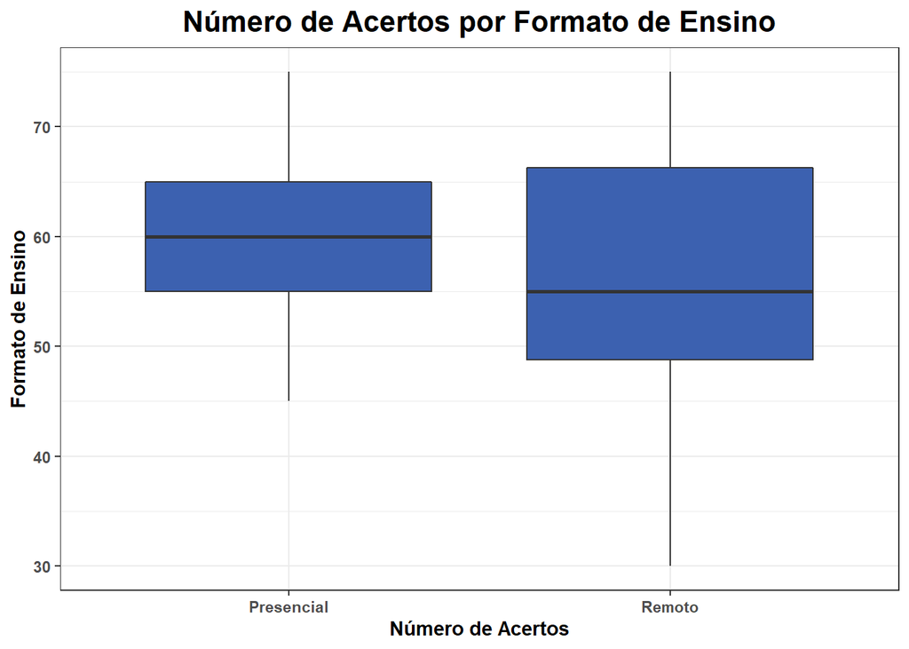

#### Hipótese

$$H_0: \mu_{\text{presencial}} =
\mu_{\text{remoto}}$$

Variável

Graus de Liberdade

Soma dos Quadrados

Média SQ

Valor F

P Valor

Formato do Ensino

1

150.000

150.000

1.083

0.309

Resíduos

22

3045.833

138.447

Como o P Valor é maior do que 0.05, não se rejeita $H_0$ a um nível de significância $\alpha$ de 5%.

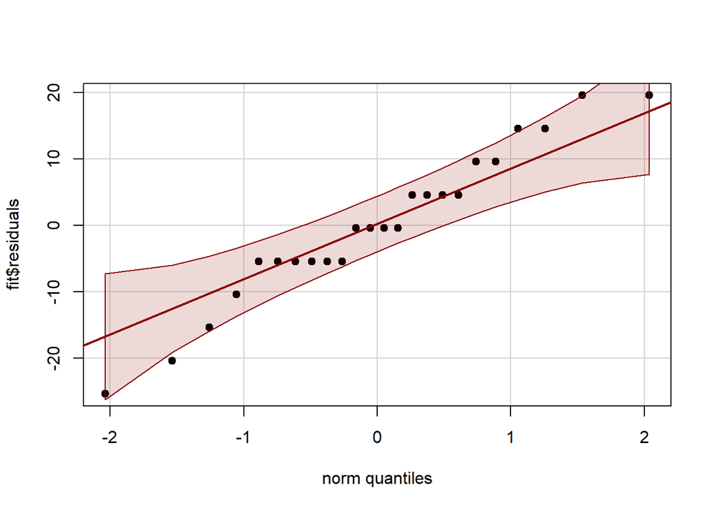

```
##
##  Shapiro-Wilk normality test
##
## data:  fit$residuals
## W = 0.96407, p-value = 0.5254
```

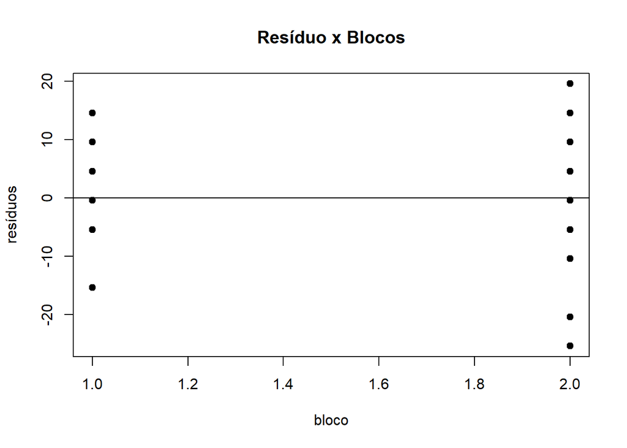

```
##
##  Bartlett test of homogeneity of variances
##
## data:  fit$residuals by df[, bloco]
## Bartlett's K-squared = 3.3974, df = 1, p-value = 0.0653
```

## Por Tratamento

| Variável | tratamento | Mediana | Média | Mínimo | Máximo | Desvio.Padrão | Variância | N |
| --- | --- | --- | --- | --- | --- | --- | --- | --- |
| numero_acertos | Com música | 62.50 | 60.42 | 35.00 | 75.00 | 10.76 | 115.72 | 12 |
| numero_acertos | Sem música | 55.00 | 55.42 | 30.00 | 75.00 | 12.70 | 161.17 | 12 |
| idade | Com música | 21.50 | 22.17 | 19.00 | 30.00 | 3.24 | 10.52 | 12 |
| idade | Sem música | 21.50 | 22.00 | 20.00 | 26.00 | 2.09 | 4.36 | 12 |
| duracao | Com música | 14.52 | 14.07 | 10.98 | 17.53 | 2.20 | 4.82 | 12 |
| duracao | Sem música | 15.18 | 16.36 | 7.28 | 27.07 | 5.78 | 33.43 | 12 |

| Variável | Grupo | tratamento | N |
| --- | --- | --- | --- |
| sexo | Feminino | Com música | 3 |
| sexo | Feminino | Sem música | 2 |
| sexo | Masculino | Com música | 9 |
| sexo | Masculino | Sem música | 10 |
| ano_ingresso | 2016 | Com música | 2 |
| ano_ingresso | 2016 | Sem música | 1 |
| ano_ingresso | 2017 | Com música | 1 |
| ano_ingresso | 2018 | Com música | 3 |
| ano_ingresso | 2018 | Sem música | 4 |
| ano_ingresso | 2019 | Sem música | 1 |
| ano_ingresso | 2020 | Com música | 4 |
| ano_ingresso | 2020 | Sem música | 5 |
| ano_ingresso | 2021 | Com música | 2 |
| ano_ingresso | 2021 | Sem música | 1 |
| formato_ensino | Presencial | Com música | 6 |
| formato_ensino | Presencial | Sem música | 6 |
| formato_ensino | Remoto | Com música | 6 |
| formato_ensino | Remoto | Sem música | 6 |
| curso | CDC | Com música | 12 |
| curso | CDC | Sem música | 12 |

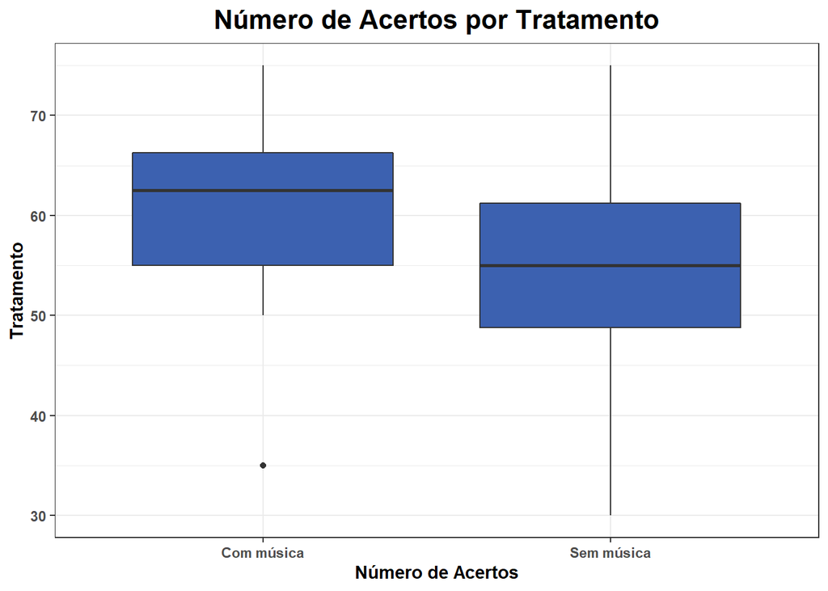

#### Hipótese

$$H_0: \mu_{\text{Com música}} =
\mu_{\text{Sem música}}$$

Variável

Graus de Liberdade

Soma dos Quadrados

Média SQ

Valor F

P Valor

Tratamento

1

150.000

150.000

1.083

0.309

Resíduos

22

3045.833

138.447

Como o P Valor é maior do que 0.05, não se rejeita $H_0$ a um nível de significância $\alpha$ de 5%.

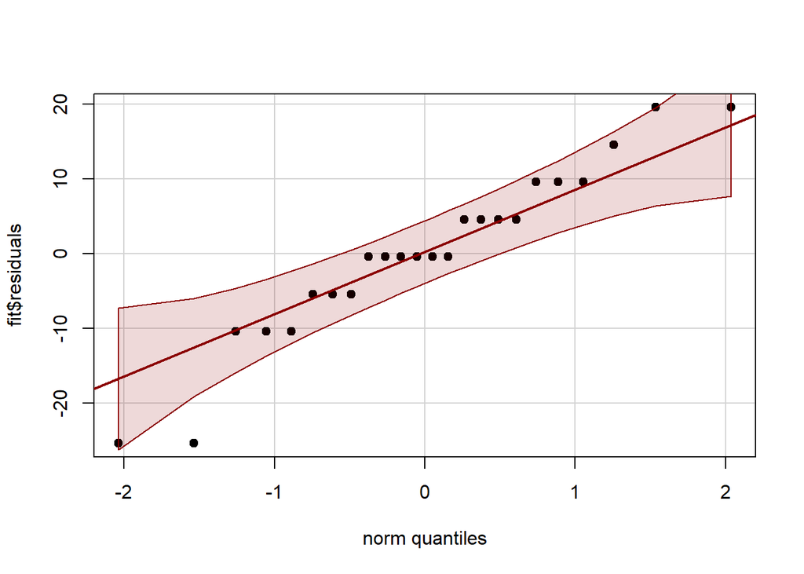

```
##
##  Shapiro-Wilk normality test
##
## data:  fit$residuals
## W = 0.9453, p-value = 0.2139
```

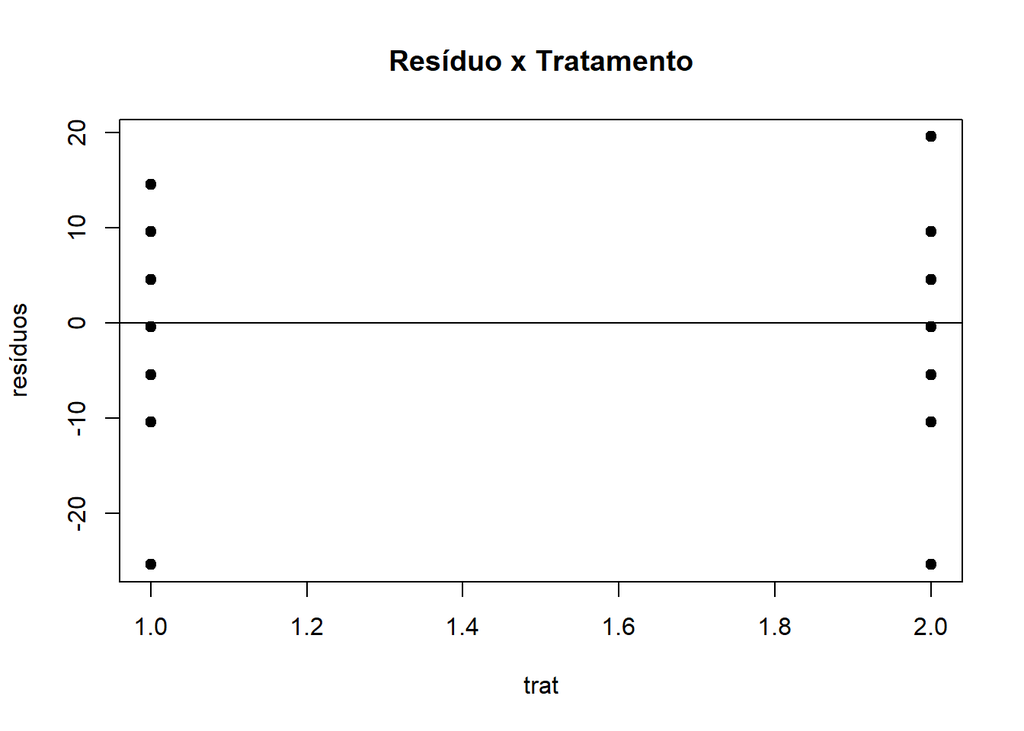

```
##
##  Bartlett test of homogeneity of variances
##
## data:  fit$residuals by df[, trat]
## Bartlett's K-squared = 0.28743, df = 1, p-value = 0.5919
```

## Por Formato de Ensino e Tratamento

| Variável | formato_ensino | tratamento | Mediana | Máximo | Desvio.Padrão | Variância | N |
| --- | --- | --- | --- | --- | --- | --- | --- |
| numero_acertos | Presencial | Com música | 62.50 | 70.00 | 5.24 | 27.50 | 6 |
| numero_acertos | Presencial | Sem música | 55.00 | 75.00 | 10.33 | 106.67 | 6 |
| numero_acertos | Remoto | Com música | 60.00 | 75.00 | 14.72 | 216.67 | 6 |
| numero_acertos | Remoto | Sem música | 52.50 | 75.00 | 15.08 | 227.50 | 6 |
| idade | Presencial | Com música | 23.50 | 30.00 | 3.08 | 9.50 | 6 |
| idade | Presencial | Sem música | 23.50 | 26.00 | 1.63 | 2.67 | 6 |
| idade | Remoto | Com música | 20.00 | 21.00 | 0.75 | 0.57 | 6 |
| idade | Remoto | Sem música | 20.00 | 21.00 | 0.52 | 0.27 | 6 |
| duracao | Presencial | Com música | 15.38 | 17.53 | 2.08 | 4.34 | 6 |
| duracao | Presencial | Sem música | 19.35 | 27.07 | 5.07 | 25.70 | 6 |
| duracao | Remoto | Com música | 12.83 | 15.72 | 2.04 | 4.17 | 6 |
| duracao | Remoto | Sem música | 12.51 | 17.58 | 3.41 | 11.64 | 6 |

| Variável | Grupo | formato_ensino | tratamento | N |
| --- | --- | --- | --- | --- |
| sexo | Feminino | Remoto | Com música | 3 |
| sexo | Feminino | Remoto | Sem música | 2 |
| sexo | Masculino | Presencial | Com música | 6 |
| sexo | Masculino | Presencial | Sem música | 6 |
| sexo | Masculino | Remoto | Com música | 3 |
| sexo | Masculino | Remoto | Sem música | 4 |
| ano_ingresso | 2016 | Presencial | Com música | 2 |
| ano_ingresso | 2016 | Presencial | Sem música | 1 |
| ano_ingresso | 2017 | Presencial | Com música | 1 |
| ano_ingresso | 2018 | Presencial | Com música | 3 |
| ano_ingresso | 2018 | Presencial | Sem música | 4 |
| ano_ingresso | 2019 | Presencial | Sem música | 1 |
| ano_ingresso | 2020 | Remoto | Com música | 4 |
| ano_ingresso | 2020 | Remoto | Sem música | 5 |
| ano_ingresso | 2021 | Remoto | Com música | 2 |
| ano_ingresso | 2021 | Remoto | Sem música | 1 |
| curso | CDC | Presencial | Com música | 6 |
| curso | CDC | Presencial | Sem música | 6 |
| curso | CDC | Remoto | Com música | 6 |
| curso | CDC | Remoto | Sem música | 6 |

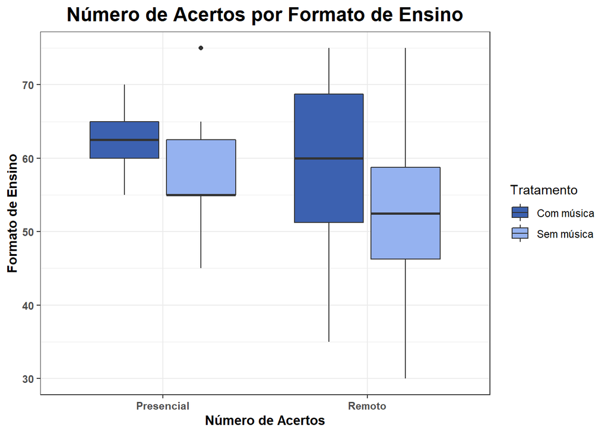

#### Hipótese

$$H_0: \mu_{\text{Com música:Presencial}}
= \mu_{\text{Com música:Remoto}} = \\ \mu_{\text{Sem música:Presencial}}
= \mu_{\text{Sem música:Remoto}}$$

Variável

Graus de Liberdade

Soma dos Quadrados

Média SQ

Valor F

P Valor

Formato do Ensino

1

150.000

150.000

1.037

0.321

Tratamento

1

150.000

150.000

1.037

0.321

Formato do Ensino : Tratamento

1

4.167

4.167

0.029

0.867

Resíduos

20

2891.667

144.583

Como o P Valor é maior do que 0.05, não se rejeita $H_0$ a um nível de significância $\alpha$ de 5%.

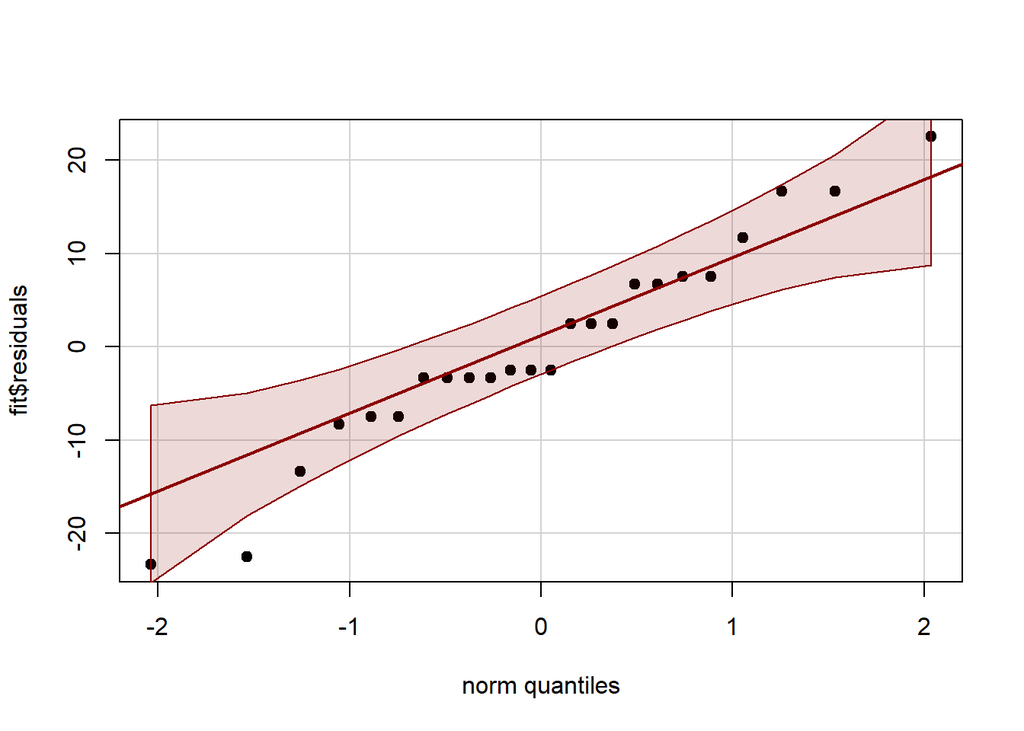

```
##
##  Shapiro-Wilk normality test
##
## data:  fit$residuals
## W = 0.9658, p-value = 0.5653
```

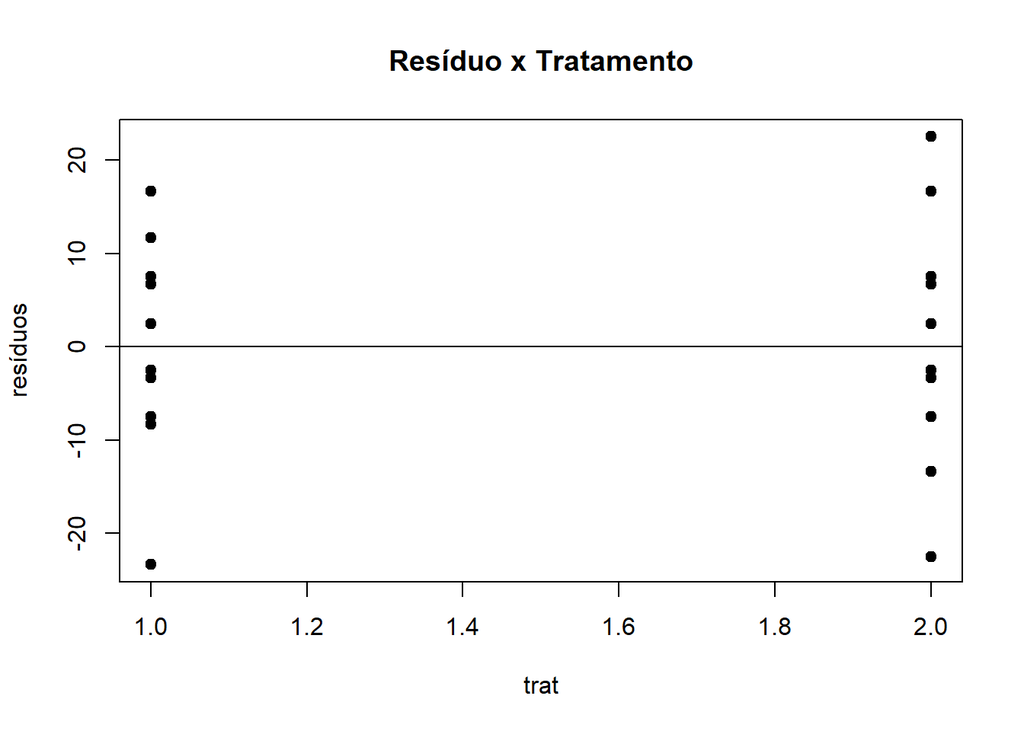

```
##
##  Bartlett test of homogeneity of variances
##
## data:  fit$residuals by df[, trat]
## Bartlett's K-squared = 0.25795, df = 1, p-value = 0.6115
```

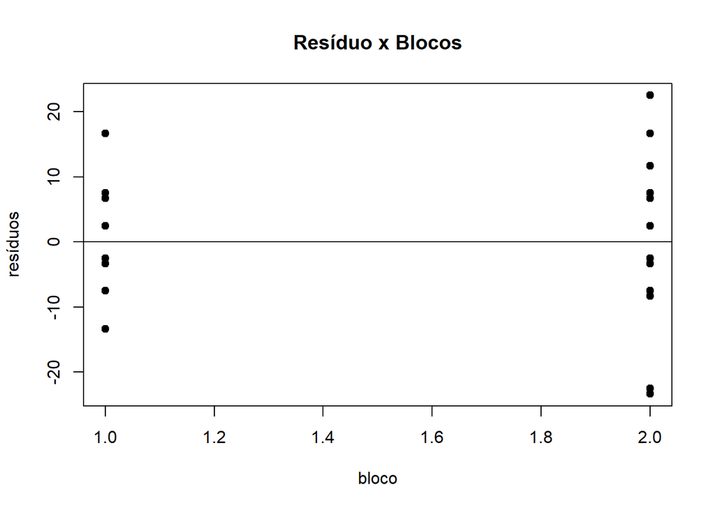

```
##
##  Bartlett test of homogeneity of variances
##
## data:  fit$residuals by df[, bloco]
## Bartlett's K-squared = 3.564, df = 1, p-value = 0.05905
```

# Análise Matemática

## Por Formato de Ensino

| Variável | formato_ensino | Mediana | Média | Mínimo | Máximo | Desvio.Padrão | Variância | N |
| --- | --- | --- | --- | --- | --- | --- | --- | --- |
| numero_acertos | Presencial | 55.00 | 59.17 | 40.00 | 80.00 | 17.44 | 304.17 | 6 |
| numero_acertos | Remoto | 55.00 | 56.67 | 40.00 | 75.00 | 16.93 | 286.67 | 6 |
| idade | Presencial | 22.00 | 21.67 | 21.00 | 22.00 | 0.52 | 0.27 | 6 |
| idade | Remoto | 19.00 | 19.50 | 19.00 | 22.00 | 1.22 | 1.50 | 6 |
| duracao | Presencial | 50.23 | 50.94 | 23.82 | 73.17 | 19.06 | 363.23 | 6 |
| duracao | Remoto | 35.64 | 38.16 | 10.62 | 70.40 | 23.45 | 549.76 | 6 |

| Variável | Grupo | formato_ensino | N |
| --- | --- | --- | --- |
| sexo | Feminino | Presencial | 2 |
| sexo | Feminino | Remoto | 4 |
| sexo | Masculino | Presencial | 4 |
| sexo | Masculino | Remoto | 2 |
| ano_ingresso | 2018 | Presencial | 1 |
| ano_ingresso | 2019 | Presencial | 5 |
| ano_ingresso | 2021 | Remoto | 6 |
| tratamento | Com música | Presencial | 3 |
| tratamento | Com música | Remoto | 3 |
| tratamento | Sem música | Presencial | 3 |
| tratamento | Sem música | Remoto | 3 |
| curso | MAT | Presencial | 6 |
| curso | MAT | Remoto | 6 |

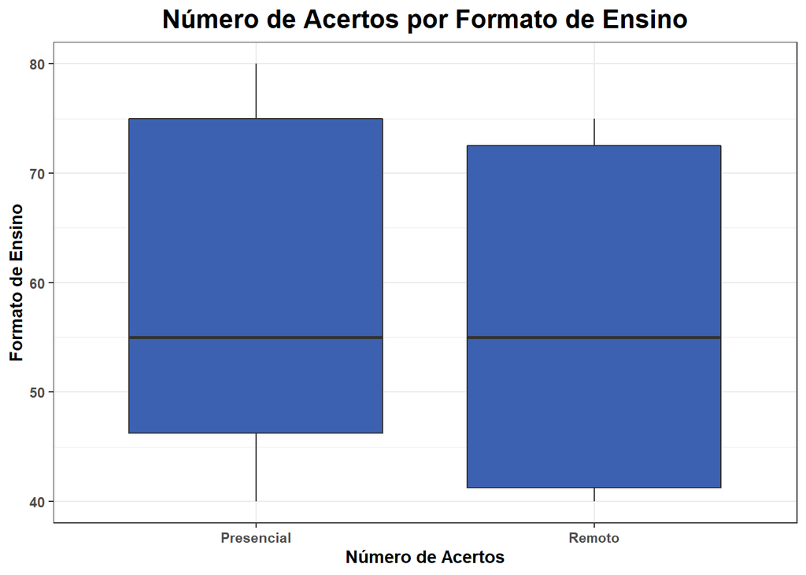

#### Hipótese

$$H_0: \mu_{\text{presencial}} =
\mu_{\text{remoto}}$$

Variável

Graus de Liberdade

Soma dos Quadrados

Média SQ

Valor F

P Valor

Formato do Ensino

1

18.750

18.750

0.063

0.806

Resíduos

10

2954.167

295.417

Como o P Valor é maior do que 0.05, não se rejeita $H_0$ a um nível de significância $\alpha$ de 5%.

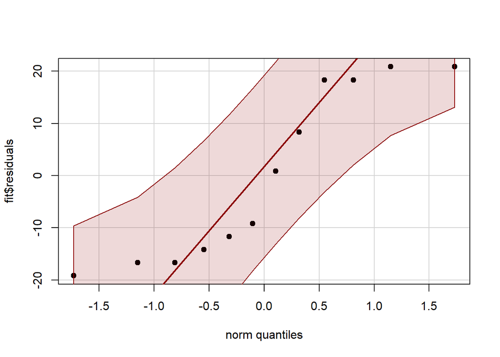

```
##
##  Shapiro-Wilk normality test
##
## data:  fit$residuals
## W = 0.84264, p-value = 0.02981
```

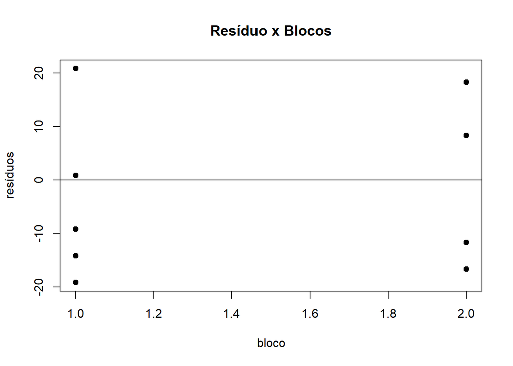

```
##
##  Bartlett test of homogeneity of variances
##
## data:  fit$residuals by df[, bloco]
## Bartlett's K-squared = 0.0039895, df = 1, p-value = 0.9496
```

Como os resíduos não ão normais, aplicaremos uma transformação nos dados.

```
## Best Normalizing transformation with 12 Observations
##  Estimated Normality Statistics (Pearson P / df, lower => more normal):
##  - arcsinh(x): 1.3333
##  - Box-Cox: 1.3333
##  - Center+scale: 2.3333
##  - Exp(x): 8
##  - Log_b(x+a): 1.3333
##  - orderNorm (ORQ): 0.3333
##  - sqrt(x + a): 1.3333
##  - Yeo-Johnson: 1.3333
## Estimation method: Out-of-sample via leave-one-out CV
##
## Based off these, bestNormalize chose:
## orderNorm Transformation with 12 nonmissing obs and ties
##  - 7 unique values
##  - Original quantiles:
##    0%   25%   50%   75%  100%
## 40.00 43.75 55.00 75.00 80.00
```

Variável

Graus de Liberdade

Soma dos Quadrados

Média SQ

Valor F

P Valor

Formato do Ensino

1

0.421

0.421

0.48

0.504

Resíduos

10

8.777

0.878

Como o P Valor é maior do que 0.05, não se rejeita $H_0$ a um nível de significância $\alpha$ de 5%.

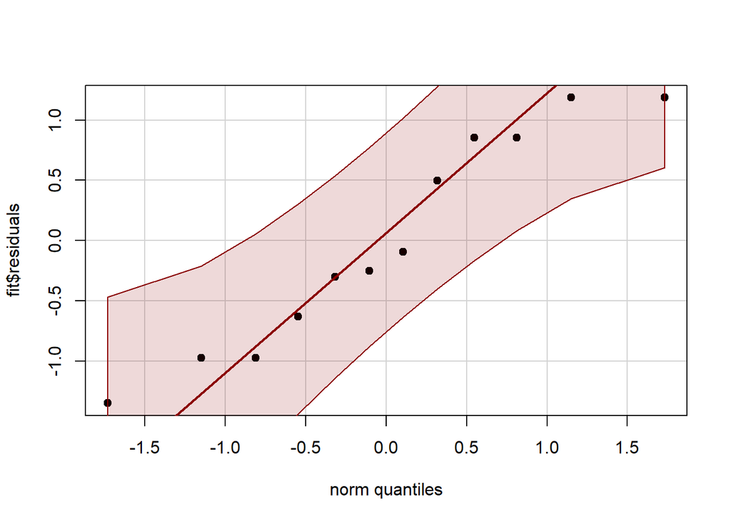

```
##
##  Shapiro-Wilk normality test
##
## data:  fit$residuals
## W = 0.92314, p-value = 0.313
```

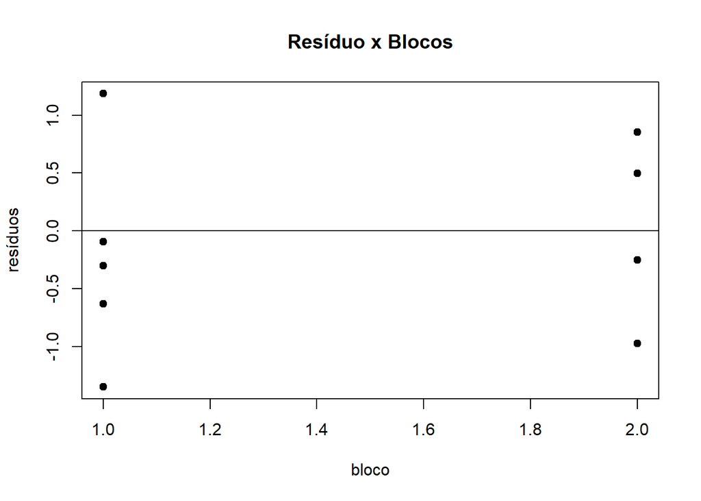

```
##
##  Bartlett test of homogeneity of variances
##
## data:  fit$residuals by df[, bloco]
## Bartlett's K-squared = 0.12882, df = 1, p-value = 0.7197
```

## Por Tratamento

| Variável | tratamento | Mediana | Média | Mínimo | Máximo | Desvio.Padrão | Variância | N |
| --- | --- | --- | --- | --- | --- | --- | --- | --- |
| numero_acertos | Com música | 75.00 | 66.67 | 40.00 | 80.00 | 17.22 | 296.67 | 6 |
| numero_acertos | Sem música | 45.00 | 49.17 | 40.00 | 65.00 | 10.68 | 114.17 | 6 |
| idade | Com música | 21.50 | 20.83 | 19.00 | 22.00 | 1.47 | 2.17 | 6 |
| idade | Sem música | 20.00 | 20.33 | 19.00 | 22.00 | 1.51 | 2.27 | 6 |
| duracao | Com música | 55.83 | 53.83 | 20.32 | 73.17 | 19.02 | 361.81 | 6 |
| duracao | Sem música | 30.96 | 35.27 | 10.62 | 70.40 | 21.04 | 442.85 | 6 |

| Variável | Grupo | tratamento | N |
| --- | --- | --- | --- |
| sexo | Feminino | Com música | 2 |
| sexo | Feminino | Sem música | 4 |
| sexo | Masculino | Com música | 4 |
| sexo | Masculino | Sem música | 2 |
| ano_ingresso | 2018 | Sem música | 1 |
| ano_ingresso | 2019 | Com música | 3 |
| ano_ingresso | 2019 | Sem música | 2 |
| ano_ingresso | 2021 | Com música | 3 |
| ano_ingresso | 2021 | Sem música | 3 |
| formato_ensino | Presencial | Com música | 3 |
| formato_ensino | Presencial | Sem música | 3 |
| formato_ensino | Remoto | Com música | 3 |
| formato_ensino | Remoto | Sem música | 3 |
| curso | MAT | Com música | 6 |
| curso | MAT | Sem música | 6 |

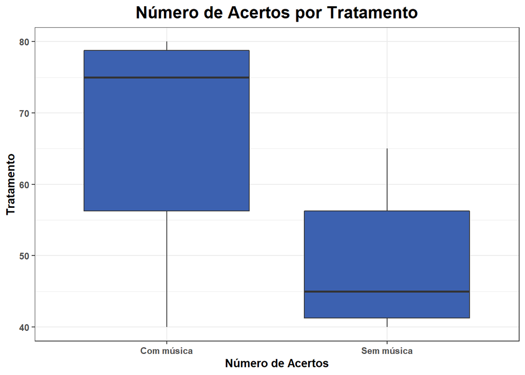

#### Hipótese

$$H_0: \mu_{\text{Com música}} =
\mu_{\text{Sem música}}$$

Variável

Graus de Liberdade

Soma dos Quadrados

Média SQ

Valor F

P Valor

Tratamento

1

918.750

918.750

4.473

0.061

Resíduos

10

2054.167

205.417

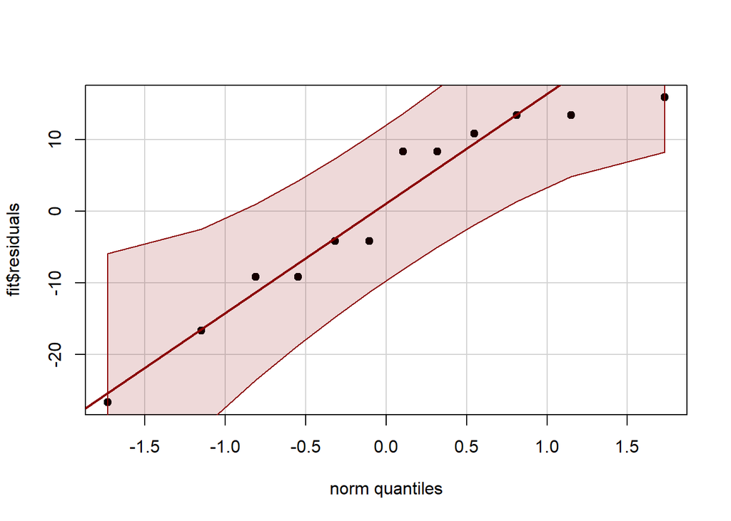

```
##
##  Shapiro-Wilk normality test
##
## data:  fit$residuals
## W = 0.90988, p-value = 0.2126
```

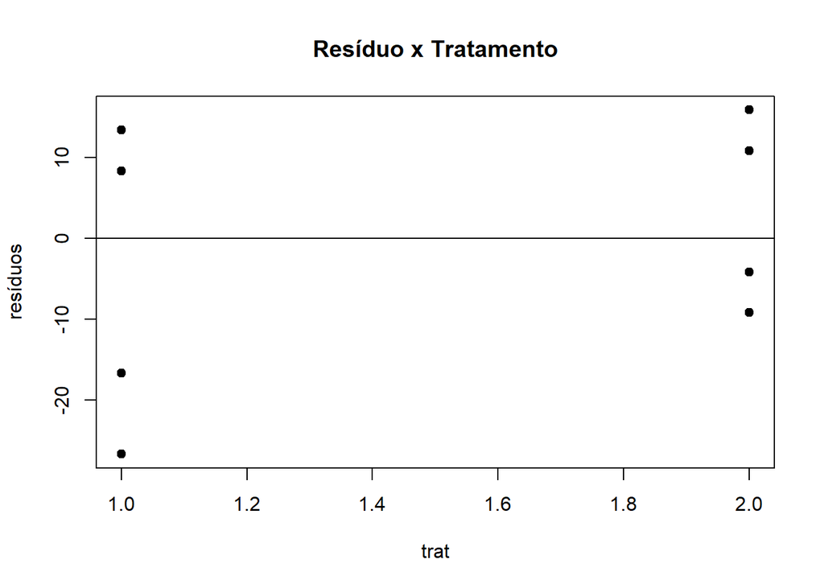

```
##
##  Bartlett test of homogeneity of variances
##
## data:  fit$residuals by df[, trat]
## Bartlett's K-squared = 0.99915, df = 1, p-value = 0.3175
```

## Por Formato de Ensino e Tratamento

| Variável | formato_ensino | tratamento | Mediana | Máximo | Desvio.Padrão | Variância | N |
| --- | --- | --- | --- | --- | --- | --- | --- |
| numero_acertos | Presencial | Com música | 80.00 | 80.00 | 17.32 | 300.00 | 3 |
| numero_acertos | Presencial | Sem música | 45.00 | 60.00 | 10.41 | 108.33 | 3 |
| numero_acertos | Remoto | Com música | 75.00 | 75.00 | 20.21 | 408.33 | 3 |
| numero_acertos | Remoto | Sem música | 45.00 | 65.00 | 13.23 | 175.00 | 3 |
| idade | Presencial | Com música | 22.00 | 22.00 | 0.58 | 0.33 | 3 |
| idade | Presencial | Sem música | 22.00 | 22.00 | 0.58 | 0.33 | 3 |
| idade | Remoto | Com música | 19.00 | 22.00 | 1.73 | 3.00 | 3 |
| idade | Remoto | Sem música | 19.00 | 19.00 | 0.00 | 0.00 | 3 |
| duracao | Presencial | Com música | 70.13 | 73.17 | 9.54 | 91.04 | 3 |
| duracao | Presencial | Sem música | 38.10 | 45.12 | 10.85 | 117.82 | 3 |
| duracao | Remoto | Com música | 47.68 | 56.32 | 18.79 | 353.24 | 3 |
| duracao | Remoto | Sem música | 23.60 | 70.40 | 31.45 | 988.81 | 3 |

| Variável | Grupo | formato_ensino | tratamento | N |
| --- | --- | --- | --- | --- |
| sexo | Feminino | Presencial | Com música | 1 |
| sexo | Feminino | Presencial | Sem música | 1 |
| sexo | Feminino | Remoto | Com música | 1 |
| sexo | Feminino | Remoto | Sem música | 3 |
| sexo | Masculino | Presencial | Com música | 2 |
| sexo | Masculino | Presencial | Sem música | 2 |
| sexo | Masculino | Remoto | Com música | 2 |
| ano_ingresso | 2018 | Presencial | Sem música | 1 |
| ano_ingresso | 2019 | Presencial | Com música | 3 |
| ano_ingresso | 2019 | Presencial | Sem música | 2 |
| ano_ingresso | 2021 | Remoto | Com música | 3 |
| ano_ingresso | 2021 | Remoto | Sem música | 3 |
| curso | MAT | Presencial | Com música | 3 |
| curso | MAT | Presencial | Sem música | 3 |
| curso | MAT | Remoto | Com música | 3 |
| curso | MAT | Remoto | Sem música | 3 |

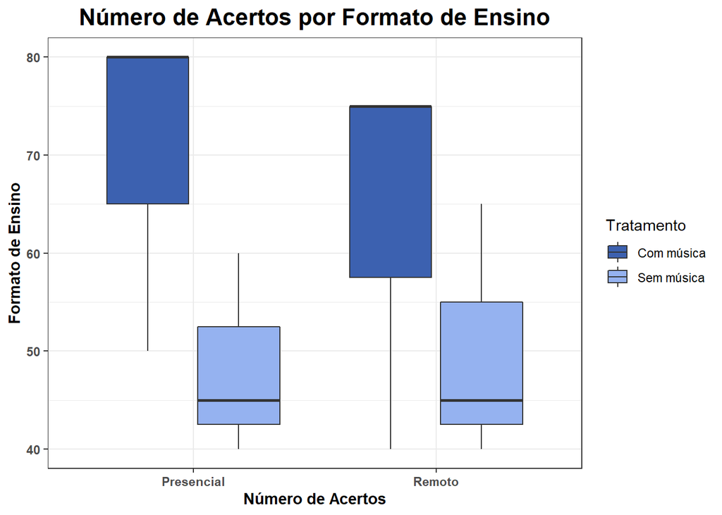

#### Hipótese

$$H_0: \mu_{\text{Com música:Presencial}}
= \mu_{\text{Com música:Remoto}} = \\ \mu_{\text{Sem música:Presencial}}
= \mu_{\text{Sem música:Remoto}}$$

Variável

Graus de Liberdade

Soma dos Quadrados

Média SQ

Valor F

P Valor

Formato do Ensino

1

18.750

18.750

0.076

0.79

Tratamento

1

918.750

918.750

3.706

0.09

Formato do Ensino : Tratamento

1

52.083

52.083

0.21

0.659

Resíduos

8

1983.333

247.917

Como o P Valor é maior do que 0.05, não se rejeita $H_0$ a um nível de significância $\alpha$ de 5%. Lembrando que a hipótese é referente a Variável Formato do Ensino : Tratamento.

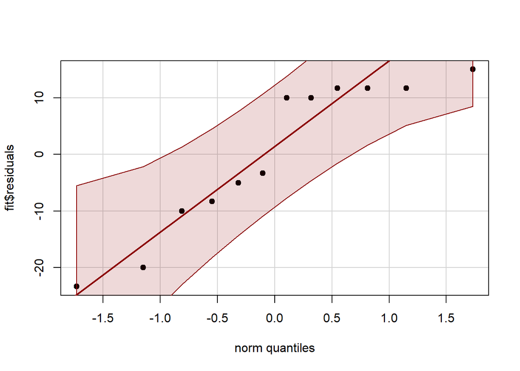

```
##
##  Shapiro-Wilk normality test
##
## data:  fit$residuals
## W = 0.87115, p-value = 0.06758
```

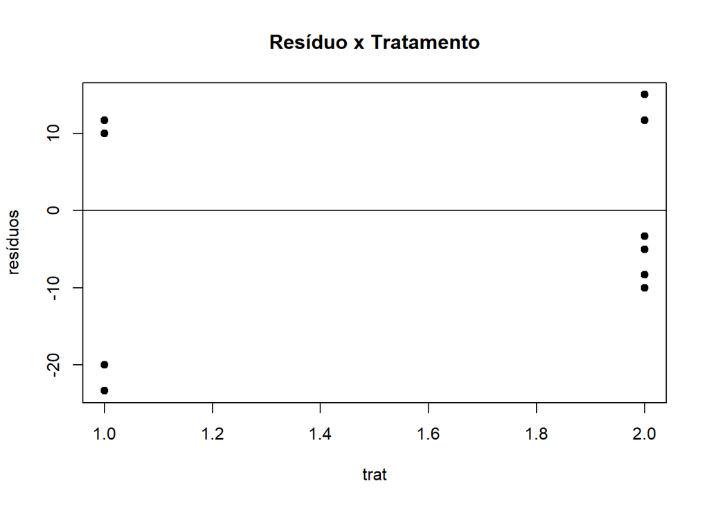

```
##
##  Bartlett test of homogeneity of variances
##
## data:  fit$residuals by df[, trat]
## Bartlett's K-squared = 0.92246, df = 1, p-value = 0.3368
```

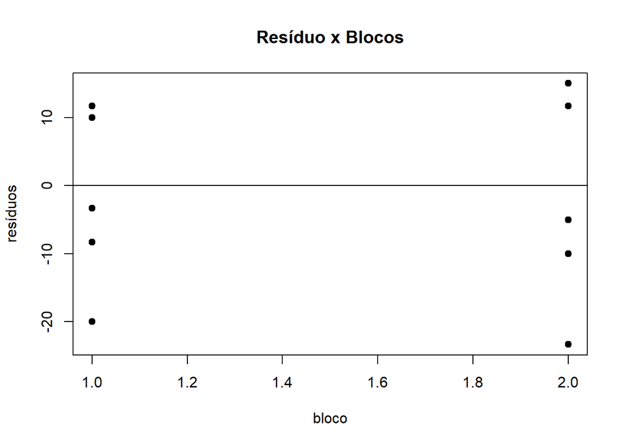

```
##
##  Bartlett test of homogeneity of variances
##
## data:  fit$residuals by df[, bloco]
## Bartlett's K-squared = 0.1438, df = 1, p-value = 0.7045
```

# Conclusão

Com este relatório foi possível observar que não há diferença significativa na porcentagem de acertos em relação a alunos que fizeram as matérias no remoto e os que fizeram no presencial.

Também foi possível aplicar os conhecimentos obtidos na matéria de Estatística Experimental e com isso melhorar nosso aprendizado.

Um agradecimento em especial de todos os integrantes ao Professor Guaraci!